# STAT5002 Lab3 Worksheet

Introduction to Statistics

University of Sydney STAT5002

# Summary

- It is vital that you draw a *quick sketch* of the Normal curve that you are considering, *before* you attempt any calculations.
- We use R to find an area under the Normal curve. Historically, ‘Stats Tables’ were used.
- The *area under the curve* up to point $x$, represents the *chance* (or “probability”) of getting a value less than or equal to $x$.

# 1 Import data and more plotting tricks

## 1.1 Data

We continue using the data set collected in MATH1005 in S2, 2022. Make sure you have the data-file `math1005_cleaned.csv` in your data folder within your STAT5002 folder.

- **Import** the data into a variable called `math1005`. Then we isolate the height variable and remove `NA`s from it.

```r
math1005 = read.csv("math1005_cleaned.csv")
str(math1005)
```

```
## 'data.frame':    281 obs. of  8 variables:
##  $ Gender       : chr  "Female" "Female" "Female" "Male" ...
##  $ International: chr  "Domestic" "Domestic" "International" "Domestic" ...
##  $ Major        : chr  "Physics, Chemistry" "Biomedical Engineering" "Statistics" "Transport" ...
##  $ Height       : num  154 182 156 172 193 167 NA 183 150 181 ...
##  $ ShoeSize     : num  9.5 9 9 8 13 40.5 NA 11 7 44 ...
##  $ Age          : int  18 22 18 29 18 19 19 18 18 20 ...
##  $ Country      : chr  "Australia" "Australia" "India" "Nepal" ...
##  $ Language     : chr  "English " "English" "Hindi" "Nepali" ...
```

```r
height = na.omit(math1005$Height)
```

## 1.2 Plot normal curve

The code `curve(dnorm(x, m, s), xlim = c(a, b), add=TRUE)` plots a normal curve with mean m and SD s in the domain $(a,b)$ on the x axis. The option `add=TRUE` let you add a normal curve to an existing plot. See the following for an example.

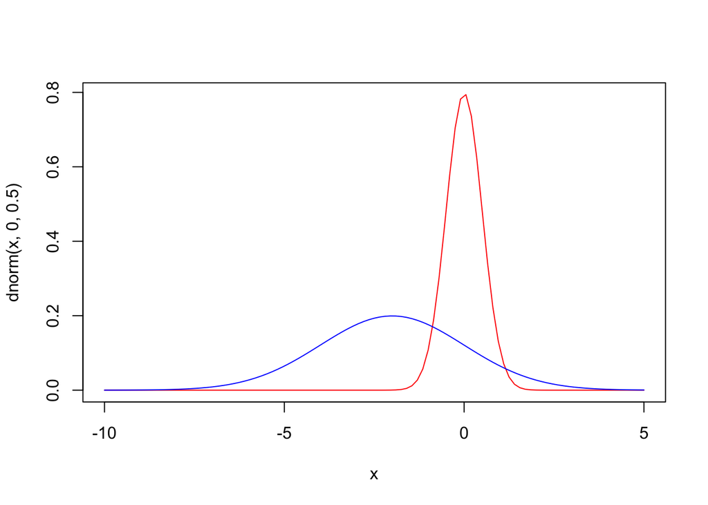

```r
### here is an example
curve(dnorm(x, 0, 0.5), xlim = c(-10, 5), col = "red")
curve(dnorm(x, -2, 2), xlim = c(-10, 5), col = "blue", add=TRUE)
```

## 1.3 Plotting area under a normal curve (in case you are curious)

The following code sketches a Normal Curve with mean 40 and SD 15. The red shaded area represents $P(X < 18)$. The blue shaded area represents $P(60 < X < 80)$.

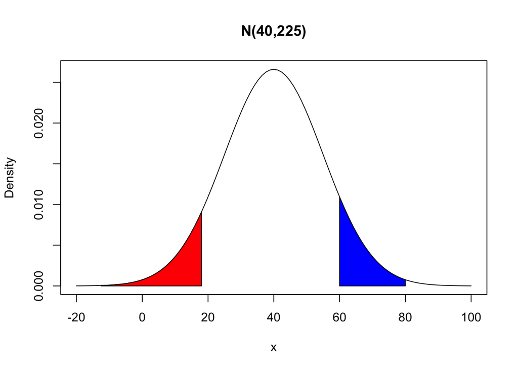

```r
curve(dnorm(x,40,15),from=-20,to=100,ylab="Density",main="N(40,225)")
x = seq(-3.5,3.5,length=1000)*15 + 40
y = dnorm(x,40,15)
y18 = dnorm(18, 40, 15)
polygon(c(min(x), x[x<18], 18, 18), c(0, y[x<18], y18 , 0), col="red")
y60 = dnorm(60, 40, 15)
y80 = dnorm(80, 40, 15)
polygon(c(60, 60, x[x>60&x<80], 80, 80), c(0, y60, y[x>60&x<80], y80, 0), col="blue")
```

# 2 Basics of Normal curve

We treat the collected heights as a sample of heights of students in U Syd. We want to fit a normal curve to the histogram of this height sample using the sample mean and sample SD.

Now, plot the histogram of height and then plot the normal curve (defined by the sample mean and sample SD) on top of it. Is the normal curve a reasonable approximation to the histogram in this example?

```r
### Write your code here
```

## 2.1 Proportion and quantiles under normal curve

- Under the normal curve, are there more students under 160 cm than students taller than 190 cm? Write R code in the following to calculate this.

```r
### Write your code here
#
```

- Under the normal curve, what is the 23% percentile of the student heights? Write R code in the following to calculate this.

```r
### Write your code here
#
```

# 3 Australian men’s AFL team and heights

## 3.1 Data modelling

Select the heights of male students from the data set. Plot a histogram of the selected heights. Construct a normal curve to approximate the histogram of male heights in `math1005`. Plot the resulting histogram and then plot the normal curve on top of it. If you have issues with obtaining the mean and SD, you can use mean = $178.84$ and SD = $6.53$,

```r
### Write your code here
```

## 3.2 Using R

For each of the following questions, try to use only `pnorm` and `qnorm` to calculate the answer. You can also apply the plotting tricks above to draw the corresponging area under the normal curve.

1. According to this [article](https://thatsamkid.com/2020/10/26/the-long-and-short-of-it/), the average height of AFL players is 188cm. What is the chance of finding an Australian man taller than 188cm?

```r
### Write your code here
```

2. The tallest AFL player in history is [Aaron Sandilands](https://en.wikipedia.org/wiki/Aaron_Sandilands) at 211cm tall. What is the chance of finding a man of height greater than Aaron Sandilands?

```r
### Write your code here
```

3. What percentage of Australian men are between 170 and 180cm?

```r
### Write your code here
```

4. What percentage of Australian men are you taller than?

```r
### Write your code here
```

5. If 90% of Australian men are below a certain height, what is that height?

```r
### Write your code here
```

6. If 40% of Australian men are above a certain height, what is that height?

```r
### Write your code here
```

7. What is the interquartile range of heights of Australian men?

```r
### Write your code here
```

## 3.3 Standard units

For the above questions 1 to 4, answer the questions again by converting the values to standard units and using the standard normal curve.

1. What is the chance of finding an Australian man taller than 188cm?

```r
### Write your code here
```

2. What is the chance of finding a man of height greater than 211cm?

```r
### Write your code here
```

3. What percentage of Australian men are between 170 and 180cm?

```r
### Write your code here
```

4. What percentage of Australian men are you taller than?

```r
### Write your code here
```

## 3.4 Calculating by hand

**Use the 68%-95%-99.7% rule to calculate the following by hand.**

- What percentage of Australian men are shorter than 198.43cm?
- What percentage of Australian men are taller than 165.78cm?
- What percentage of Australian men are between 172.31cm and 191.9cm?
- What is the 97.5th percentile of heights of Australian men?
- What is the 2.5th percentile of heights of Australian men?
- Write down an interval which contains 95% of the heights.

# 4 Correlation coefficient

We want to explore the association between shoesize and height. Now we want to use all data points in `math1005`.

## 4.1 First attempt

- What is the correlation coefficient of the two variables? - use `cor`. Hint: the argument use = “complete” will ignore NA values.

```r
### Write your code here
```

- Produce a **scatterplot** using the `plot` function.

```r
### Write your code here
```

- How would you describe the association between shoesize and height? Hint: Some might response using a different shoe size convention, perhaps using EU instead of US. The majority of students reported US shoesize.

**Answer:**

## 4.2 Removing outliers

Since the majority of students reported US shoesize, let’s discard data points with shoesize > 20 as outliers, and then repeat the above procedure, what is your finding?

```r
### Write your code here
```

**Answer:**

## 4.3 More about correlation coefficient

Using the data without outliers, verifying the following properties of the correlation coefficient using R.

- Verify that the correlation coefficient is not affected by interchanging the variables (**symmetry**).

```r
### Write your code here
```

- The conversion from US shoesize to EU shoesize approximately follows the formula `EU ShoeSize` = `US ShoeSize` x 1.27 + 30. Now transform the cleaned shoesizes (assuming they are US sizes) into EU sizes. Then verify that the correlation coefficient is shift and scale invariant.

```r
### Write your code here
```